# Lab 10 - Time Series Data Analysis

Cameron Wonchoba

04/07/2020

# Overview

In this notebook we will be analyzing a data set that has a time series nature. Specifically, the data set has measurements for the thickness of ice every month since 1990.

During this analysis, we will look for trends and seasonality, understand if the dataset exhibits stationarity, analyze ACF and PACF graphs, perform a seasonal decomposition of the data set, and build models to forecast what the thickness of the ice might be in the future.

We will do the forecasting using the following two models:

- ARIMA
- SARIMA

> NOTE: During the creation of this notebook, I relied heavily on research from external sources. I did my best to give credit and sources where needed.

# Data

The data set we will be using is called "sea_ice.csv" and can be found at https://timeseries.weebly.com/data-sets.html. This data has three columns:

- Time (Time the data was recorded)
- Arctic (ice content (measurement unknown))
- Antarctica (ice content (measurment unknown))

For the purposes of this analysis, we will not be analyzing Antarctica data.

```python
import pandas as pd
import numpy as np
```

```python
sea_ice_df = pd.read_csv("sea_ice.csv")
sea_ice_df.head()
```

|  | Time | Arctic | Antarctica |
| --- | --- | --- | --- |
| 0 | 1990M01 | 12.72 | 3.27 |
| 1 | 1990M02 | 13.33 | 2.15 |
| 2 | 1990M03 | 13.44 | 2.71 |
| 3 | 1990M04 | 12.16 | 5.10 |
| 4 | 1990M05 | 10.84 | 7.37 |

# Preprocessing steps

```python
# Prune out Antarctica data
ice_df = sea_ice_df.drop("Antarctica", axis=1)
ice_df.head(2)
```

|  | Time | Arctic |
| --- | --- | --- |
| 0 | 1990M01 | 12.72 |
| 1 | 1990M02 | 13.33 |

```python
# Format time column to an actual time.
ice_df["Time"] = pd.to_datetime(ice_df["Time"], format="%YM%m")
ice_df.head(2)
```

|  | Time | Arctic |
| --- | --- | --- |
| 0 | 1990-01-01 | 12.72 |
| 1 | 1990-02-01 | 13.33 |

# Exploratory Data Analysis

```python
from matplotlib import pyplot as plt
import seaborn as sns
plt.style.use('seaborn')
```

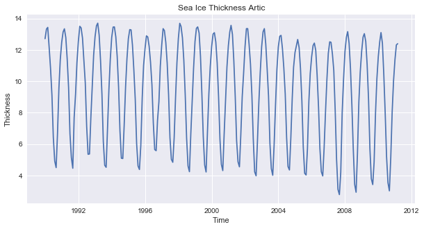

```python
# Lets first plot the sea_ice vs time.
plt.figure(figsize=(10,5))
plt.plot(ice_df["Time"], ice_df['Arctic'])
plt.title("Sea Ice Thickness Artic")
plt.ylabel('Thickness')
plt.xlabel('Time')
```

## Does this graph exhibit Stationarity?

`Constant Mean` - Yes, mostly

`Constant Variation` - Yes

`No Seasonality` - **No**

This data set does **NOT** exhibit constant seasonality as it mimics a cosine wave (almost start at its peak). The fact that this graph displays an oscillating nature means that seasonality is present and it does not exhibit stationarity.

## Looking closer

We will look closer into the data and exhibit a two year time between 2009 and 2010.

```python
# Get a whole month worth of data for 2010
ice_df[ice_df["Time"] == "2009-01-01"]
```

|  | Time | Arctic |
| --- | --- | --- |
| 228 | 2009-01-01 | 11.91 |

2009 starts at index **228** and 2010 ends at index 228+24months = **251**

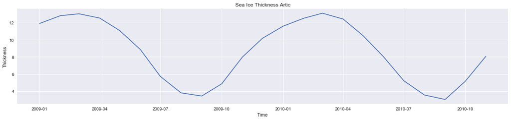

```python
# Plotting the year 2009 to 2010
plt.figure(figsize=(20,4))
plt.plot(ice_df['Time'][228:251], ice_df['Arctic'][228:251])
plt.title("Sea Ice Thickness Artic")
plt.ylabel('Thickness')
plt.xlabel('Time')
```

We can see that each year, the ice becomes most thick in March (winter months), and least thick in August and September (summer months). This makes sense.

## Dickey-Fuller Test

This test tells us how strongly a time series is defined by a trend by checking if there is a unit root. A unit root is a stochastic trend and the presence of one tells us that the pattern is unpredictable.

`NULL Hypothesis`: Suggests that the time series data has a unit root, meaning it is non-stationary.

`Alternative Hypothesis`: Suggests that the time series data does not have a unit root, meaning it is stationary.

We will reject the Null Hypothesis if we see a p-value lower the .05 (a 95% confidence level).

Sources:

https://machinelearningmastery.com/time-series-data-stationary-python/

https://www.statisticshowto.com/unit-root/

```python
from statsmodels.tsa.stattools import adfuller
df_test = adfuller(ice_df['Arctic'], autolag='AIC', maxlag = 50)

print('Results of Dickey-Fuller Test:\n')
print("Test Statistic: {0}\npvalue: {1}".format(df_test[0], df_test[1]))
```

```
Results of Dickey-Fuller Test:

Test Statistic: -0.021271961187830594
pvalue: 0.9567371555032318
```

The pvalue of 0.95 (which is greater than 0.05) confirms our strong suspicions. The dataset is not stationary.

## Apply the Difference Operation

This will tell us how many times we need to difference our dataset (parameter d in the ARIMA model).

Once we are able to reject the NULL Hypothesis, we will know how many difference operations are needed.

https://machinelearningmastery.com/difference-time-series-dataset-python/

```python
diff = ice_df['Arctic'].diff().dropna()

df_test = adfuller(diff, autolag='AIC', maxlag = 50)

print('Results of Dickey-Fuller Test:\n')
print("Test Statistic: {0}\npvalue: {1}".format(df_test[0], df_test[1]))
```

```
Results of Dickey-Fuller Test:

Test Statistic: -4.673725199581872
pvalue: 9.425523589249332e-05
```

# ACF and PACF plots

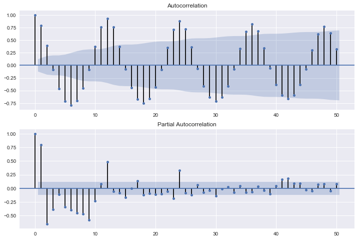

```python
#plot the ACF and PACF plots
import statsmodels.api as sm

fig = plt.figure(figsize=(12,8))
ax1 = fig.add_subplot(211)
fig = sm.graphics.tsa.plot_acf(ice_df['Arctic'].diff().dropna(), lags=50, ax=ax1)
ax2 = fig.add_subplot(212)
fig = sm.graphics.tsa.plot_pacf(ice_df['Arctic'].diff().dropna(), lags=50, ax=ax2)
plt.show()
```

### Autocorrelation

This tells us the autocorrelation between some point and another point at previous point in time. This includes direct and indirect dependencies.

### Partial Autocorrelation

This also tells us the autocorrelation between some point and another point at a previous time. However, partial autocorrelation only includes direct dependencies (t-1->t)

### AutoRegressive

According to the source below, if the PACF graph experiences a more sharp cutoff while the ACF graph experiences a more a gradual decay, we can say that the data displays an "AR signature". Further, if the first lag is a positve correlation this further indicates that we should add an AR term to the model. We should add as many AR terms that we see a significant correlation in the PACF graph.

We will add somewhere between 10 and 12 AR terms (we may try both).

This means that `p=10 or p=12`

### Moving Average

Directly from the source below "If the ACF of the differenced series displays a sharp cutoff and/or the lag-1 autocorrelation is negative--i.e., if the series appears slightly "overdifferenced"--then consider adding an MA term to the model. The lag at which the ACF cuts off is the indicated number of MA terms."

I will not be adding a Moving average term as there is not a sharp cutoff or a negative lag-1 autocorrelation.

This means that `q=0`

Sources:

https://people.duke.edu/~rnau/411arim3.htm

## Seasonal Decomposition

This method will break down our data set by the following components:

- Seasonal
- Trend
- Residuals

This will allow us to see how present each of these components are in our dataset with the noise of the other components.

More on this later...

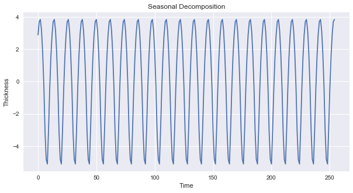

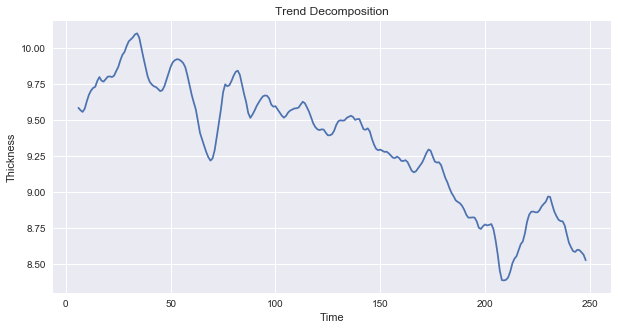

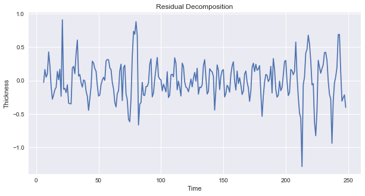

```python
from statsmodels.tsa.seasonal import seasonal_decompose
seasonal = seasonal_decompose(ice_df['Arctic'], period=12)

# Lets first plot the sea_ice vs time.
plt.figure(figsize=(10,5))
plt.plot(seasonal.seasonal)
plt.title("Seasonal Decomposition")
plt.ylabel('Thickness')
plt.xlabel('Time')
plt.show()

# Lets first plot the sea_ice vs time.
plt.figure(figsize=(10,5))
plt.plot(seasonal.trend)
plt.title("Trend Decomposition")
plt.ylabel('Thickness')
plt.xlabel('Time')
plt.show()

# Lets first plot the sea_ice vs time.
plt.figure(figsize=(10,5))
plt.plot(seasonal.resid)
plt.title("Residual Decomposition")
plt.ylabel('Thickness')
plt.xlabel('Time')
plt.show()
```

## Seasonal Decomposition

This method broke down our time series into three different components. The seasonal, trend and residual component.

### Seasonal

The seasonal component tells us if there is a seasonal component (ie. something happen once a year). This was pretty obvious in the original data set, and it is obvious here. There is a definte seasonal component.

### Trend

The trend component tells us if there are any trends in our data set. In the original data set it was very difficult to tell if the thickness of the ice was trending down or not. However, the trend component clearly shows us that the thickness of the ice is trending downwards.

### Residual

The Residual component tells us how much noise is in the dataset (I think?). From the graph above, we can see that there is a random amount of noise, but it does tend to get large as time goes on.

# ARIMA

### p = the number of autoregressive terms

p is the number of autoregressive terms (AR part). It allows to incorporate the effect of past values into our model. Intuitively, this would be similar to stating that it is likely to be warm tomorrow if it has been warm the past 3 days.

### d = the number of nonseasonal differences

d is the number of nonseasonal differences needed for stationarity. Intuitively, this would be similar to stating that it is likely to be same temperature tomorrow if the difference in temperature in the last three days has been very small.

### q = the number of moving-average terms

q is the number of lagged forecast errors in the prediction equation (MA part). This allows us to set the error of our model as a linear combination of the error values observed at previous time points in the past.

https://towardsdatascience.com/unboxing-arima-models-1dc09d2746f8

## Selecting model parameters

`p`: 10 or 12

`d`: 1

`q`: 0

The reasoning for these parameters are described in the above Jupyter Notebook.

```python
# Train test split
train, test = ice_df[:241], ice_df[241:]
train.shape
test.shape
test.head()
```

|  | Time | Arctic |
| --- | --- | --- |
| 241 | 2010-02-01 | 12.52 |
| 242 | 2010-03-01 | 13.11 |
| 243 | 2010-04-01 | 12.43 |
| 244 | 2010-05-01 | 10.48 |
| 245 | 2010-06-01 | 7.98 |

```python
from statsmodels.tsa.arima_model import ARIMA
model = ARIMA(train['Arctic'], order=(10,1,0))
model_fit = model.fit()
display(model_fit.summary())
print("AIC: ", model_fit.aic)
```

ARIMA Model Results

| Dep. Variable: | D.Arctic | No. Observations: | 240 |
| --- | --- | --- | --- |
| Model: | ARIMA(10, 1, 0) | Log Likelihood | -91.987 |
| Method: | css-mle | S.D. of innovations | 0.341 |
| Date: | Tue, 07 Apr 2020 | AIC | 207.974 |
| Time: | 21:25:41 | BIC | 249.742 |
| Sample: | 1 | HQIC | 224.803 |

|  | coef | std err | z | P>\|z\| | [0.025 | 0.975] |
| --- | --- | --- | --- | --- | --- | --- |
| const | -0.0034 | 0.004 | -0.770 | 0.441 | -0.012 | 0.005 |
| ar.L1.D.Arctic | -0.1792 | nan | nan | nan | nan | nan |
| ar.L2.D.Arctic | -0.3220 | 0.041 | -7.888 | 0.000 | -0.402 | -0.242 |
| ar.L3.D.Arctic | -0.5572 | 0.058 | -9.650 | 0.000 | -0.670 | -0.444 |
| ar.L4.D.Arctic | -0.3881 | 0.020 | -19.541 | 0.000 | -0.427 | -0.349 |
| ar.L5.D.Arctic | -0.4048 | 0.035 | -11.436 | 0.000 | -0.474 | -0.335 |
| ar.L6.D.Arctic | -0.4406 | 0.076 | -5.810 | 0.000 | -0.589 | -0.292 |
| ar.L7.D.Arctic | -0.4273 | 0.054 | -7.949 | 0.000 | -0.533 | -0.322 |
| ar.L8.D.Arctic | -0.3357 | 0.046 | -7.355 | 0.000 | -0.425 | -0.246 |
| ar.L9.D.Arctic | -0.5937 | 0.038 | -15.779 | 0.000 | -0.667 | -0.520 |
| ar.L10.D.Arctic | -0.4288 | nan | nan | nan | nan | nan |

Roots

|  | Real | Imaginary | Modulus | Frequency |
| --- | --- | --- | --- | --- |
| AR.1 | 0.8665 | -0.4993j | 1.0001 | -0.0832 |
| AR.2 | 0.8665 | +0.4993j | 1.0001 | 0.0832 |
| AR.3 | 0.5016 | -0.8761j | 1.0095 | -0.1672 |
| AR.4 | 0.5016 | +0.8761j | 1.0095 | 0.1672 |
| AR.5 | -0.0645 | -1.0663j | 1.0683 | -0.2596 |
| AR.6 | -0.0645 | +1.0663j | 1.0683 | 0.2596 |
| AR.7 | -0.7866 | -0.8354j | 1.1475 | -0.3702 |
| AR.8 | -0.7866 | +0.8354j | 1.1475 | 0.3702 |
| AR.9 | -1.2093 | -0.2454j | 1.2340 | -0.4681 |
| AR.10 | -1.2093 | +0.2454j | 1.2340 | 0.4681 |

```
AIC:  207.9740008733491
```

```python
from statsmodels.tsa.arima_model import ARIMA
model = ARIMA(train['Arctic'], order=(12,1,0))
model_fit = model.fit()
display(model_fit.summary())
print("AIC: ", model_fit.aic)
```

ARIMA Model Results

| Dep. Variable: | D.Arctic | No. Observations: | 240 |
| --- | --- | --- | --- |
| Model: | ARIMA(12, 1, 0) | Log Likelihood | -75.150 |
| Method: | css-mle | S.D. of innovations | 5430146228.989 |
| Date: | Tue, 07 Apr 2020 | AIC | 178.301 |
| Time: | 21:28:23 | BIC | 227.030 |
| Sample: | 1 | HQIC | 197.935 |

|  | coef | std err | z | P>\|z\| | [0.025 | 0.975] |
| --- | --- | --- | --- | --- | --- | --- |
| const | -0.0033 | 3.17e-06 | -1046.685 | 0.000 | -0.003 | -0.003 |
| ar.L1.D.Arctic | -0.1923 | 6.21e-06 | -3.1e+04 | 0.000 | -0.192 | -0.192 |
| ar.L2.D.Arctic | -0.2784 | 1.22e-05 | -2.28e+04 | 0.000 | -0.278 | -0.278 |
| ar.L3.D.Arctic | -0.3827 | 3.46e-05 | -1.11e+04 | 0.000 | -0.383 | -0.383 |
| ar.L4.D.Arctic | -0.3171 | 1.28e-05 | -2.48e+04 | 0.000 | -0.317 | -0.317 |
| ar.L5.D.Arctic | -0.3168 | 2.74e-05 | -1.16e+04 | 0.000 | -0.317 | -0.317 |
| ar.L6.D.Arctic | -0.3300 | nan | nan | nan | nan | nan |
| ar.L7.D.Arctic | -0.3245 | 5.52e-06 | -5.88e+04 | 0.000 | -0.325 | -0.324 |
| ar.L8.D.Arctic | -0.2853 | nan | nan | nan | nan | nan |
| ar.L9.D.Arctic | -0.4323 | nan | nan | nan | nan | nan |
| ar.L10.D.Arctic | -0.2949 | 0.000 | -1185.280 | 0.000 | -0.295 | -0.294 |
| ar.L11.D.Arctic | -0.1253 | 0.000 | -1160.812 | 0.000 | -0.126 | -0.125 |
| ar.L12.D.Arctic | 0.3699 | 4.29e-06 | 8.62e+04 | 0.000 | 0.370 | 0.370 |

Roots

|  | Real | Imaginary | Modulus | Frequency |
| --- | --- | --- | --- | --- |
| AR.1 | -1.0481 | -0.0000j | 1.0481 | -0.5000 |
| AR.2 | -0.9289 | -0.5490j | 1.0790 | -0.4151 |
| AR.3 | -0.9289 | +0.5490j | 1.0790 | 0.4151 |
| AR.4 | -0.5664 | -0.9431j | 1.1001 | -0.3361 |
| AR.5 | -0.5664 | +0.9431j | 1.1001 | 0.3361 |
| AR.6 | -0.0156 | -1.0407j | 1.0408 | -0.2524 |
| AR.7 | -0.0156 | +1.0407j | 1.0408 | 0.2524 |
| AR.8 | 0.5008 | -0.8709j | 1.0047 | -0.1669 |
| AR.9 | 0.5008 | +0.8709j | 1.0047 | 0.1669 |
| AR.10 | 0.8664 | -0.4993j | 1.0000 | -0.0832 |
| AR.11 | 0.8664 | +0.4993j | 1.0000 | 0.0832 |
| AR.12 | 1.6743 | -0.0000j | 1.6743 | -0.0000 |

```
AIC:  178.3006218780422
```

Using p = 12 resulted in a lower AIC of **178.3** and a BIC of **227.030**, so we will use that model.

## Predictions using Forecast

Grab the next 14 predictions that have never been seen by the model.

```python
predictions = model_fit.forecast(steps = 14)[0]
```

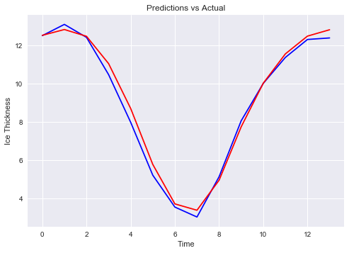

```python
## Plot them along with our testing data
plt.plot(test['Arctic'].to_numpy(), color='blue')
plt.plot(predictions, color='red')
plt.title("Predictions vs Actual")
plt.ylabel("Ice Thickness")
plt.xlabel("Time")
```

## Evaluation of ARIMA using Mean Squared Error

```python
# Calculate the mean squared error
from sklearn.metrics import mean_squared_error

mse = mean_squared_error(test['Arctic'].to_numpy(), predictions)

print("Mean Squared Error: ", mse)
```

```
Mean Squared Error:  0.1276902948848433
```

Hey! That looks really good!

Our graph maps really close to each other, and we got a mean squared error of 0.128.

This feels like it will be hard to beat, but we will try another model.

# SARIMA

### Whats wrong with ARIMA?

Before we go into SARIMA, we should point out what is wrong with ARIMA.

ARIMA is good for forecasting data, but it does not handle seasonal data well.

### SARIMA

SARIMA is built off of ARIMA, and it supports seasonal data (such as the data set we are using here).

There are four new parameters:

- P: Seasonal autoregressive order.
- D: Seasonal difference order.
- Q: Seasonal moving average order.
- m: The number of time steps for a single seasonal period.

```python
# Note Train and Test are still split the same as before
print(train.shape)
test.shape
```

```
(241, 2)
```

```
(14, 2)
```

## Selecting parameters

Per Duke University, a few rules are defined:

### Differencing (d)

If the series has a strong and consistent seasonal pattern, then you should use an order of seasonal differencing--but never use more than one order of seasonal differencing or more than 2 orders of total differencing (seasonal+nonseasonal).

We have a strong and consistent season pattern, so we set differencing, `d = 1`.

### AutoRegressive (p) and Moving Average (q)

If the autocorrelation at the seasonal period is positive, consider adding an SAR term to the model. If the autocorrelation at the seasonal period is negative, consider adding an SMA term to the model. Try to avoid mixing SAR and SMA terms in the same model, and avoid using more than one of either kind.

The autocorrelation at the seasonal period is positive, so we will add a SAR term to the model. We will try `p = 1` and `q = 0`.

### Periodicity

The number of periods in season. We have monthly data, so we will use 12. This can be verified in our ACF graph where the highest lag is at 1 and again at 12. This means that we will try `s = 12`.

Source:

https://people.duke.edu/~rnau/seasarim.htm

```python
from statsmodels.tsa.statespace.sarimax import SARIMAX

model = SARIMAX(train['Arctic'], order=(10,1,0), seasonal_order=(1,1,0,12))
model_fit = model.fit()
display(model_fit.summary())
print("AIC: ", model_fit.aic)
```

SARIMAX Results

| Dep. Variable: | Arctic | No. Observations: | 241 |
| --- | --- | --- | --- |
| Model: | SARIMAX(10, 1, 0)x(1, 1, 0, 12) | Log Likelihood | -44.084 |
| Date: | Tue, 07 Apr 2020 | AIC | 112.169 |
| Time: | 21:31:53 | BIC | 153.321 |
| Sample: | 0 | HQIC | 128.773 |
|  | - 241 |  |  |
| Covariance Type: | opg |  |  |

|  | coef | std err | z | P>\|z\| | [0.025 | 0.975] |
| --- | --- | --- | --- | --- | --- | --- |
| ar.L1 | -0.1812 | 0.063 | -2.896 | 0.004 | -0.304 | -0.059 |
| ar.L2 | -0.2590 | 0.081 | -3.209 | 0.001 | -0.417 | -0.101 |
| ar.L3 | -0.2493 | 0.077 | -3.253 | 0.001 | -0.400 | -0.099 |
| ar.L4 | -0.1661 | 0.077 | -2.150 | 0.032 | -0.317 | -0.015 |
| ar.L5 | -0.2432 | 0.075 | -3.241 | 0.001 | -0.390 | -0.096 |
| ar.L6 | -0.1242 | 0.079 | -1.569 | 0.117 | -0.279 | 0.031 |
| ar.L7 | -0.2896 | 0.062 | -4.688 | 0.000 | -0.411 | -0.168 |
| ar.L8 | -0.1579 | 0.079 | -1.998 | 0.046 | -0.313 | -0.003 |
| ar.L9 | -0.1738 | 0.083 | -2.100 | 0.036 | -0.336 | -0.012 |
| ar.L10 | -0.0929 | 0.080 | -1.156 | 0.248 | -0.250 | 0.065 |
| ar.S.L12 | -0.6248 | 0.052 | -12.014 | 0.000 | -0.727 | -0.523 |
| sigma2 | 0.0840 | 0.007 | 11.226 | 0.000 | 0.069 | 0.099 |

| Ljung-Box (Q): | 40.17 | Jarque-Bera (JB): | 21.10 |
| --- | --- | --- | --- |
| Prob(Q): | 0.46 | Prob(JB): | 0.00 |
| Heteroskedasticity (H): | 0.74 | Skew: | -0.26 |
| Prob(H) (two-sided): | 0.20 | Kurtosis: | 4.40 |

Warnings:  
[1] Covariance matrix calculated using the outer product of gradients (complex-step).

```
AIC:  112.16890730753144
```

Using p = 10 and s = 12 resulted in a lower AIC of **112.16** and a BIC of **153.321**. This beat the previous ARIMA model.

> NOTE: We swtiched to p=10 (instead of 12) because it is not allowed to use the same autoregressive terms in both the non-seasonal and seasonal parts.

## Predictions using Forecast

Grab the next 14 predictions that have never been seen by the model.

This is the same thing we did for the ARIMA model.

```python
predictions = model_fit.forecast(steps = 14)
```

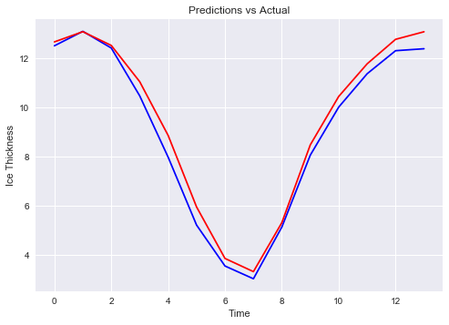

```python
## Plot them along with our testing data
plt.plot(test['Arctic'].to_numpy(), color='blue')
plt.plot(predictions.to_numpy(), color='red')
plt.title("Predictions vs Actual")
plt.ylabel("Ice Thickness")
plt.xlabel("Time")
```

## Evaluation of SARIMA using Mean Squared Error

```python
# Calculate the mean squared error
from sklearn.metrics import mean_squared_error

mse = mean_squared_error(test['Arctic'].to_numpy(), predictions)

print("Mean Squared Error: ", mse)
```

```
Mean Squared Error:  0.22397206416443471
```

This also looks really good!

We have a graph that matches really closely to its true values, and we got a really low mean squared value of 0.224.

Even though our AIC was lower in the SARIMA, the Mean Squared Error was a bit worse.

# Conclusions

We were able to analyze time series data, and make accurate predictions with ~240 data points. This shows me how powerful time series data can be.

### SARIMA

The SARIMA model was also highly predictive. I recieved an AIC of 112.169 and a mean squared error of 0.224. This tells me that there was very little in error in the forecasting of the next 14 months as well.

## Model Selection

I pick this model even though it had a slightly worse mean squared error. However, the mean squared errors were very close to each other, and almost seemed to have no difference of the actual predictions (visualized by the plots).

# Summary of this Notebook

### EDA

I visualized the data and plotted the whole set vs time as well as just two years vs time.

### ACF and PACF graphs

These graphs were useful for helping me select the parameters of my model. Essentially, ACF tells us direct and indirect autocorrelations between a point at a certain time and a point at a different time. PACF does the same thing, but does not include indirect correlations.

### Seasonal Decomposition

I was able to break down the data set into three different components that helped me visualize it better, without the noise of the other components. These components were "seasonality", "trend", and "residuals". When I did this, I was able to confirm the seasonality, and I learned that there was a negative trend.

### Modeling

I built two models, `ARIMA` and `SARIMA`. These models both performed quite well (verified by the mean squared error metric). I end up selected the SARIMA model because it has a lower AIC and it is optimized for the kind of data set that I was working with.

## Extra Things to Note

I could have easily ran a grid search on the parameters to identify which would optimize the model best. However, I wanted to fully understand what the parameters meant, and why they would be selected.

This assignment made me go from no-experience to noob in Time Series modeling. I now have context and a plan of attack for the next time I encounter a time series dataset. Thanks.